# Session 2: Homework 1

Group 7: Sarah Jiang, Danqing Sun, Lasse Munk, Shawn Wu, Pieter Vercruysse, Christian Pizzuti

2020-10-19

# 1 Where Do People Drink The Most Beer, Wine And Spirits?

In this section, we are going to discuss where people drink the most beer, wine and spirits.

We we would like to install the package and data in the beginning.

```r
#Install the fivethirtyeight package  - as the data used in the question, i.e."drinks" is part of the package

library(fivethirtyeight)
data(drinks)
```

Before we start, we want to answer these questions: What are the variable types? Any missing values we should worry about?

```r
#Summarize the data
glimpse(drinks)
```

```
## Rows: 193
## Columns: 5
## $ country                      <chr> "Afghanistan", "Albania", "Algeria", "...
## $ beer_servings                <int> 0, 89, 25, 245, 217, 102, 193, 21, 261...
## $ spirit_servings              <int> 0, 132, 0, 138, 57, 128, 25, 179, 72, ...
## $ wine_servings                <int> 0, 54, 14, 312, 45, 45, 221, 11, 212, ...
## $ total_litres_of_pure_alcohol <dbl> 0.0, 4.9, 0.7, 12.4, 5.9, 4.9, 8.3, 3....
```

```r
skim(drinks)
```

Data summary

| Name | drinks |
| --- | --- |
| Number of rows | 193 |
| Number of columns | 5 |
| _______________________ |  |
| Column type frequency: |  |
| character | 1 |
| numeric | 4 |
| ________________________ |  |
| Group variables | None |

**Variable type: character**

| skim_variable | n_missing | complete_rate | min | max | empty | n_unique | whitespace |
| --- | --- | --- | --- | --- | --- | --- | --- |
| country | 0 | 1 | 3 | 28 | 0 | 193 | 0 |

**Variable type: numeric**

| skim_variable | n_missing | complete_rate | mean | sd | p0 | p25 | p50 | p75 | p100 | hist |
| --- | --- | --- | --- | --- | --- | --- | --- | --- | --- | --- |
| beer_servings | 0 | 1 | 106.16 | 101.14 | 0 | 20.0 | 76.0 | 188.0 | 376.0 | ▇▃▂▂▁ |
| spirit_servings | 0 | 1 | 80.99 | 88.28 | 0 | 4.0 | 56.0 | 128.0 | 438.0 | ▇▃▂▁▁ |
| wine_servings | 0 | 1 | 49.45 | 79.70 | 0 | 1.0 | 8.0 | 59.0 | 370.0 | ▇▁▁▁▁ |
| total_litres_of_pure_alcohol | 0 | 1 | 4.72 | 3.77 | 0 | 1.3 | 4.2 | 7.2 | 14.4 | ▇▃▅▃▁ |

*Answer:*The variable type for “country” column is character. The variable type for “beer_servings”, “spirit_servings” and “wine_servings” is integer. The variable type for “total_litres_of_pure_alcohol” is double. There is no missing value in any of the columns.

Here, we make a plot that shows the top 25 beer consuming countries first.

```r
#Select the top 25 beer consuming countries
beer_plot <- drinks %>%
  arrange(desc(beer_servings)) %>%
  select(country, beer_servings) %>%
  head(25)

#Run the table
beer_plot
```

```
## # A tibble: 25 x 2
##    country        beer_servings
##    <chr>                  <int>
##  1 Namibia                  376
##  2 Czech Republic           361
##  3 Gabon                    347
##  4 Germany                  346
##  5 Lithuania                343
##  6 Poland                   343
##  7 Venezuela                333
##  8 Ireland                  313
##  9 Palau                    306
## 10 Romania                  297
## # ... with 15 more rows
```

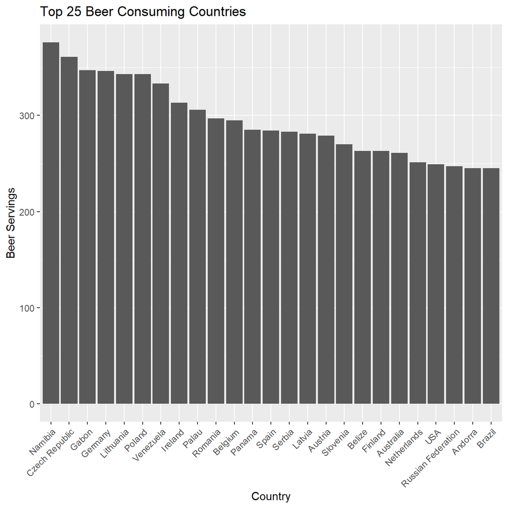

```r
#Make the plot
ggplot(beer_plot,aes(x=reorder(country,-beer_servings),y=beer_servings))+
  labs(title = "Top 25 Beer Consuming Countries", x="Country", y = "Beer Servings")+
  geom_bar(stat="identity")+
  theme(axis.text.x = element_text(angle = 45, hjust = 1))
```

Next, we make a plot that shows the top 25 wine consuming countries

```r
#Select the top 25 wine consuming countries
wine_plot <- drinks %>%
  arrange(desc(wine_servings)) %>%
  select(country, wine_servings) %>%
  head(25)

#Run the table
wine_plot
```

```
## # A tibble: 25 x 2
##    country           wine_servings
##    <chr>                     <int>
##  1 France                      370
##  2 Portugal                    339
##  3 Andorra                     312
##  4 Switzerland                 280
##  5 Denmark                     278
##  6 Slovenia                    276
##  7 Luxembourg                  271
##  8 Croatia                     254
##  9 Italy                       237
## 10 Equatorial Guinea           233
## # ... with 15 more rows
```